# GO analyses for meox1

```r
# plot gene expr
plt_name <- "top15_LECs_GO_pathways_downregulated_geneexpr_dotplot_curated"
ego_lecs_pathways <- c(
    "lymphangiogenesis",
    "lymph vessel morphogenesis",
    "lymph vessel development",
    "angiogenesis",
    "blood vessel morphogenesis"
    )
ego_lecs_selected_rows <- ego_lecs_top15_pathways[
    ego_lecs_top15_pathways$ego_lecs.Description %in% ego_lecs_pathways,
    ]
ego_lecs_genes_per_pathway <- setNames(
    strsplit(ego_lecs_selected_rows$ego_lecs.geneID, "/"),
    ego_lecs_selected_rows$ego_lecs.Description
    )
ego_lecs_genes_per_pathway <- c(unique(
    unlist(ego_lecs_genes_per_pathway)
    ), "meox1")
cat("\nGene quantity: ", length(ego_lecs_genes_per_pathway))
```

Gene quantity: 34

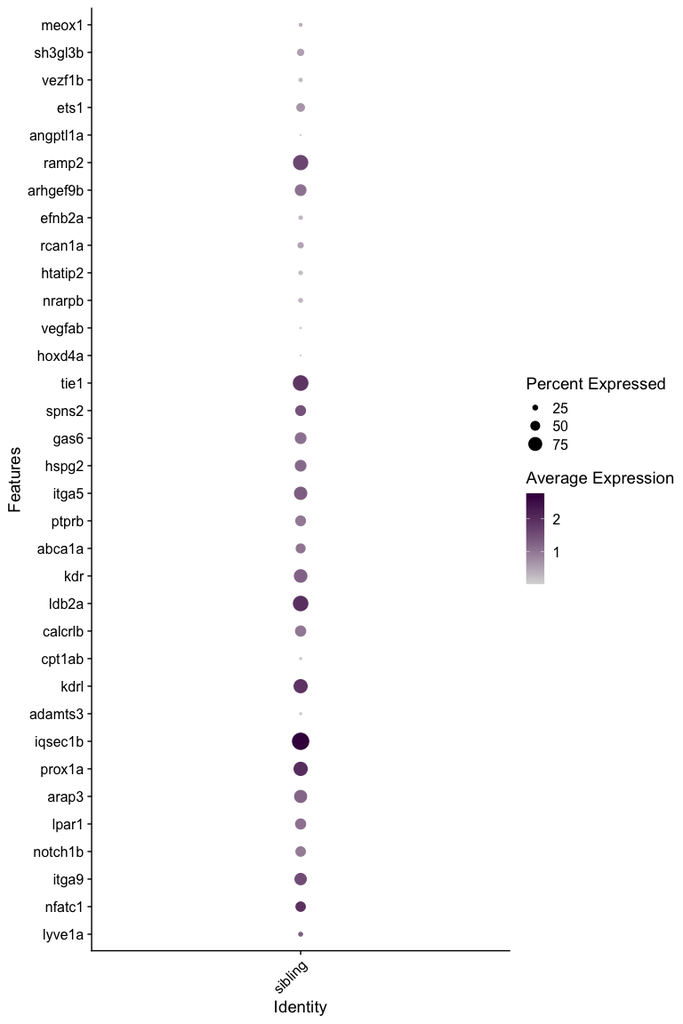

```r
plt <- DotPlot(data_lecs, features=ego_lecs_genes_per_pathway,
    group.by="Genotype", cols=c("#d9d9d9",  "#40004b")
    ) +
    coord_flip() +
    theme(axis.text.x = element_text(angle = 45, vjust = 1, hjust = 1))
print(plt)
```

```r
save_plot_custom(plt, plt_name, height=12, width=4)
```

*PDF saved to:* `../output/figure_extended/go//top15_LECs_GO_pathways_downregulated_geneexpr_dotplot_curated.pdf`

```r
cat("\n\n_Suggested figure legend:_ Violin plot shows the log2 normalised expression level for differentially expressed genes associated with enriched GO terms. Units on the horizontal axis correspond to the genotypes. Genes were selected by membership in key pathways detected by gene enrichment and ontology analyses: lymphoangiogenesis, lymph vessel morphogenesis, lymph vessel development, angiogenesis, and blood vessel morphogenesis. In addition, meox1 is shown for reference.\n\n")
```

```r
cat("\n_Tyrone: Not every single canonical gene associated with the pathway will be shown. It is a function of the data, only the differentially expressed genes associated with the GO term will be shown._\n\n")
```

*Tyrone: Not every single canonical gene associated with the pathway will be shown. It is a function of the data, only the differentially expressed genes associated with the GO term will be shown.*

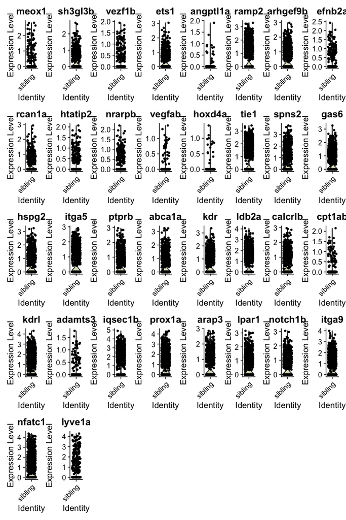

```r
plt_name <- "top15_LECs_GO_pathways_downregulated_geneexpr_vlnplot_curated"
plt <- VlnPlot(
    data_lecs,
    features = rev(ego_lecs_genes_per_pathway),
    group.by = "Genotype",
    pt.size = 1,
    ncol = 8,
    flip = TRUE,
    cols = c("#dbe2c6", "#657c95")
) + scale_fill_manual(values = c("#dbe2c6", "#657c95")) +
    theme(axis.text.x = element_text(angle = 45, vjust = 1, hjust = 1))
print(plt)
```

```r
save_plot_custom(plt, plt_name, height=16, width=16)
```

*PDF saved to:* `../output/figure_extended/go//top15_LECs_GO_pathways_downregulated_geneexpr_vlnplot_curated.pdf`

```r
singles_LEC_out <- run_go(singles_LEC, data_name="LEC")
```

## 1.6 GO analysis: LEC

Input genes: 15771

**ORA input genes:** combined = 1499 up = 944 down = 555

**ORA (combined):** 2559 terms **ORA (up):** 2116 terms **ORA (down):** 1742 terms

*Full ORA ( combined ) table saved to:* `../output/figure_extended/go//LEC_ego_combined_full_results.csv`

*Full ORA ( up ) table saved to:* `../output/figure_extended/go//LEC_ego_up_full_results.csv`

*Full ORA ( down ) table saved to:* `../output/figure_extended/go//LEC_ego_down_full_results.csv`

**ORA significant terms:** combined = 128 , up = 124 , down = 15

*Significant-only ORA ( combined ) table saved to:* `../output/figure_extended/go//LEC_ego_combined_significant_only.csv`

*Significant-only ORA ( up ) table saved to:* `../output/figure_extended/go//LEC_ego_up_significant_only.csv`

*Significant-only ORA ( down ) table saved to:* `../output/figure_extended/go//LEC_ego_down_significant_only.csv`

### 1.6.1 ORA ( combined ): Barplot

Shows the top enriched GO terms ranked by significance, bar length/colour reflecting adjusted p-value or gene count. **Expected:** terms biologically consistent with the comparison (e.g. vascular/endothelial terms for EC-related contrasts). **Unexpected:** dominance by generic housekeeping terms (translation, metabolism) with no thematic coherence - may indicate a weak or noisy input gene list rather than a real signal.

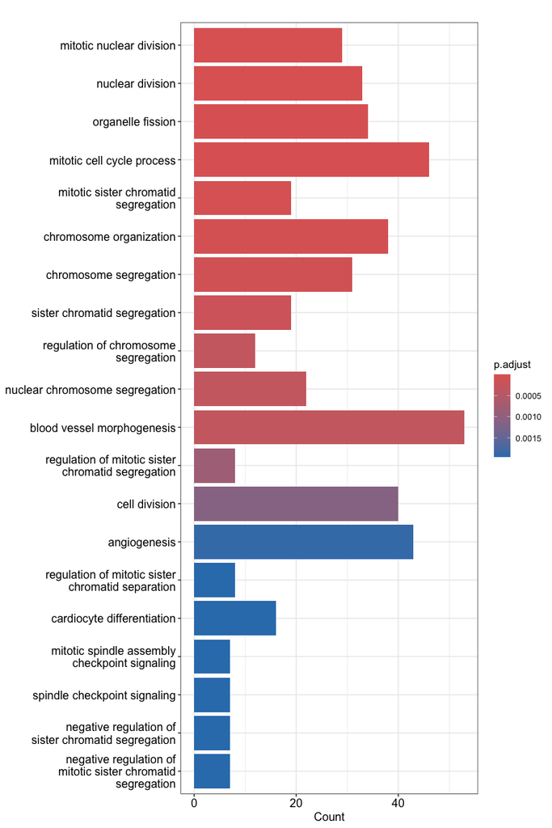

*PDF saved to:* `../output/figure_extended/go//LEC_ego_combined_barplot.pdf`

### 1.6.2 ORA ( combined ): Dotplot

Adds gene ratio (fraction of input genes hitting each term) as point size, with colour for significance - more informative than the barplot since it shows both effect size and confidence simultaneously. **Expected:** larger, more significant dots clustering around a coherent biological theme. **Unexpected:** significant terms with very small gene ratios (few genes driving a ‘significant’ result) - treat cautiously as potentially fragile.

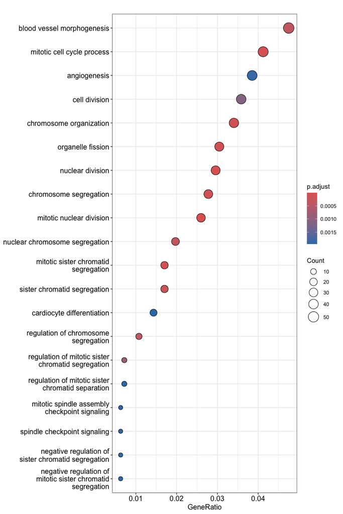

*PDF saved to:* `../output/figure_extended/go//LEC_ego_combined_dotplot.pdf`

### 1.6.3 ORA ( combined ): Enrichment map

Network graph connecting GO terms that share overlapping genes - clusters of connected terms suggest a shared underlying biological process rather than independent findings. **Expected:** tight clusters of related terms. **Unexpected:** many isolated, unconnected terms, suggesting the significant terms are thematically scattered rather than coherent.

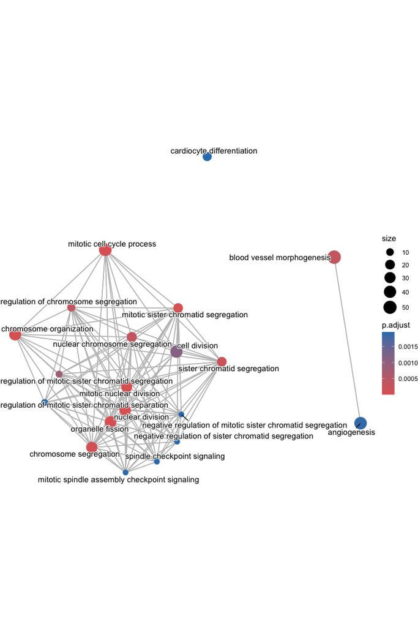

*PDF saved to:* `../output/figure_extended/go//LEC_ego_combined_emapplot.pdf`

### 1.6.4 ORA ( combined ): Category-gene network

Shows which specific genes drive which enriched terms, useful for tracing a term back to the actual DE genes behind it. **Expected:** recognisable marker genes linking to expected terms. **Unexpected:** a term driven entirely by one or two genes rather than a broad gene set - weaker evidence than a term supported by many genes.

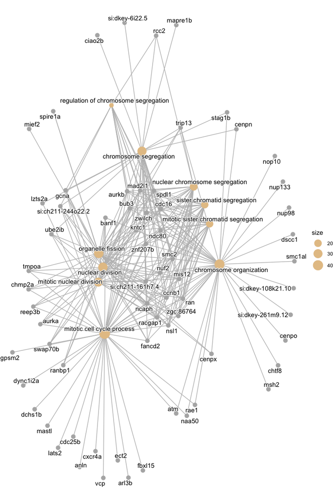

*PDF saved to:* `../output/figure_extended/go//LEC_ego_combined_cnetplot.pdf`

### 1.6.5 ORA ( up ): Barplot

Shows the top enriched GO terms ranked by significance, bar length/colour reflecting adjusted p-value or gene count. **Expected:** terms biologically consistent with the comparison (e.g. vascular/endothelial terms for EC-related contrasts). **Unexpected:** dominance by generic housekeeping terms (translation, metabolism) with no thematic coherence - may indicate a weak or noisy input gene list rather than a real signal.

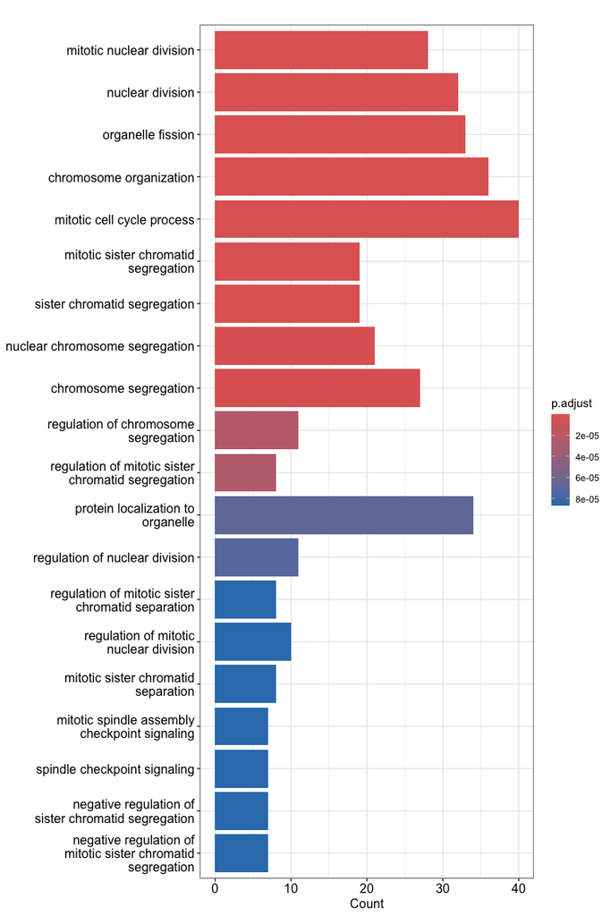

*PDF saved to:* `../output/figure_extended/go//LEC_ego_up_barplot.pdf`

### 1.6.6 ORA ( up ): Dotplot

Adds gene ratio (fraction of input genes hitting each term) as point size, with colour for significance - more informative than the barplot since it shows both effect size and confidence simultaneously. **Expected:** larger, more significant dots clustering around a coherent biological theme. **Unexpected:** significant terms with very small gene ratios (few genes driving a ‘significant’ result) - treat cautiously as potentially fragile.

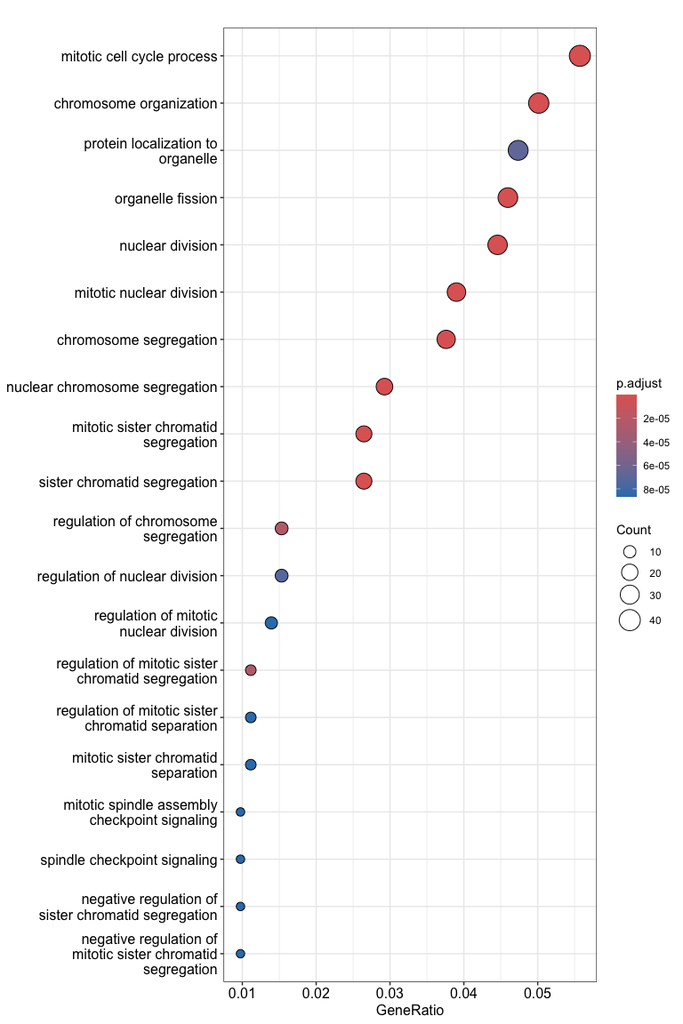

*PDF saved to:* `../output/figure_extended/go//LEC_ego_up_dotplot.pdf`

### 1.6.7 ORA ( up ): Enrichment map

Network graph connecting GO terms that share overlapping genes - clusters of connected terms suggest a shared underlying biological process rather than independent findings. **Expected:** tight clusters of related terms. **Unexpected:** many isolated, unconnected terms, suggesting the significant terms are thematically scattered rather than coherent.

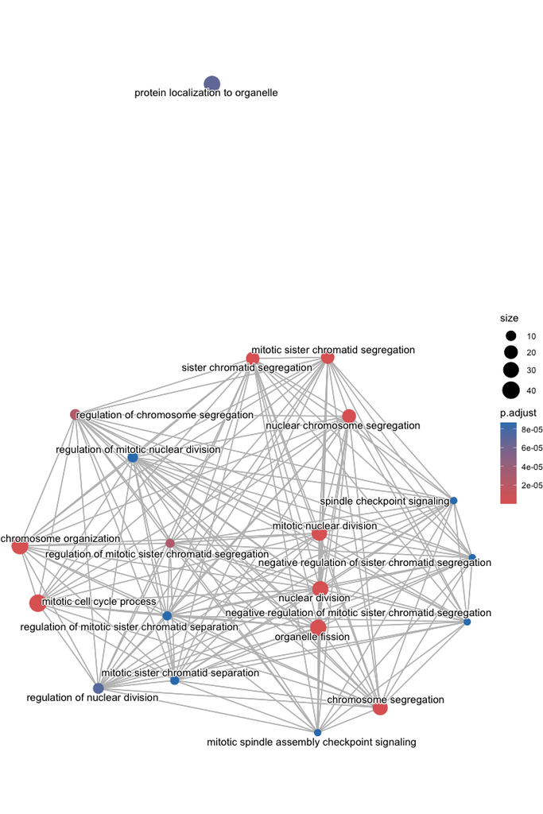

*PDF saved to:* `../output/figure_extended/go//LEC_ego_up_emapplot.pdf`

### 1.6.8 ORA ( up ): Category-gene network

Shows which specific genes drive which enriched terms, useful for tracing a term back to the actual DE genes behind it. **Expected:** recognisable marker genes linking to expected terms. **Unexpected:** a term driven entirely by one or two genes rather than a broad gene set - weaker evidence than a term supported by many genes.

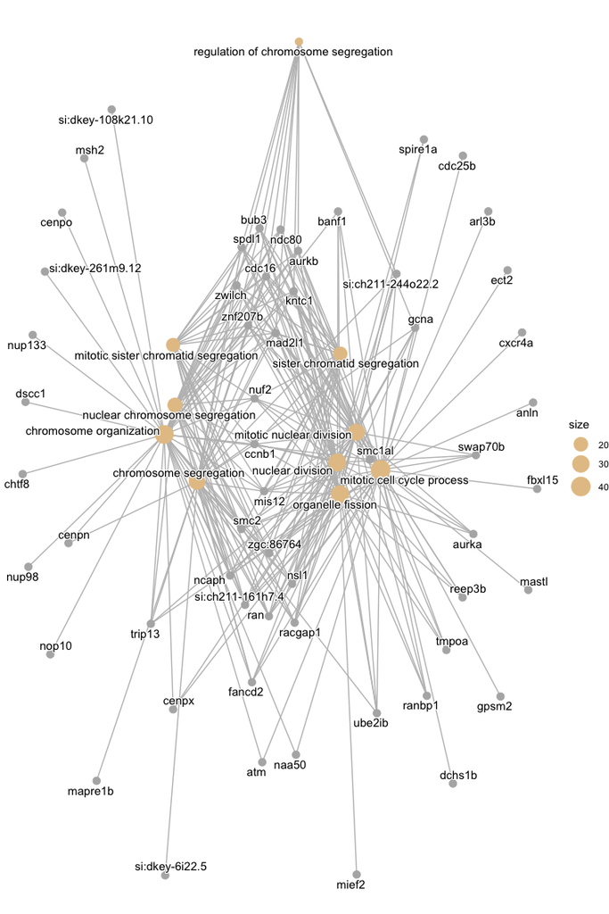

*PDF saved to:* `../output/figure_extended/go//LEC_ego_up_cnetplot.pdf`

### 1.6.9 ORA ( down ): Barplot

Shows the top enriched GO terms ranked by significance, bar length/colour reflecting adjusted p-value or gene count. **Expected:** terms biologically consistent with the comparison (e.g. vascular/endothelial terms for EC-related contrasts). **Unexpected:** dominance by generic housekeeping terms (translation, metabolism) with no thematic coherence - may indicate a weak or noisy input gene list rather than a real signal.

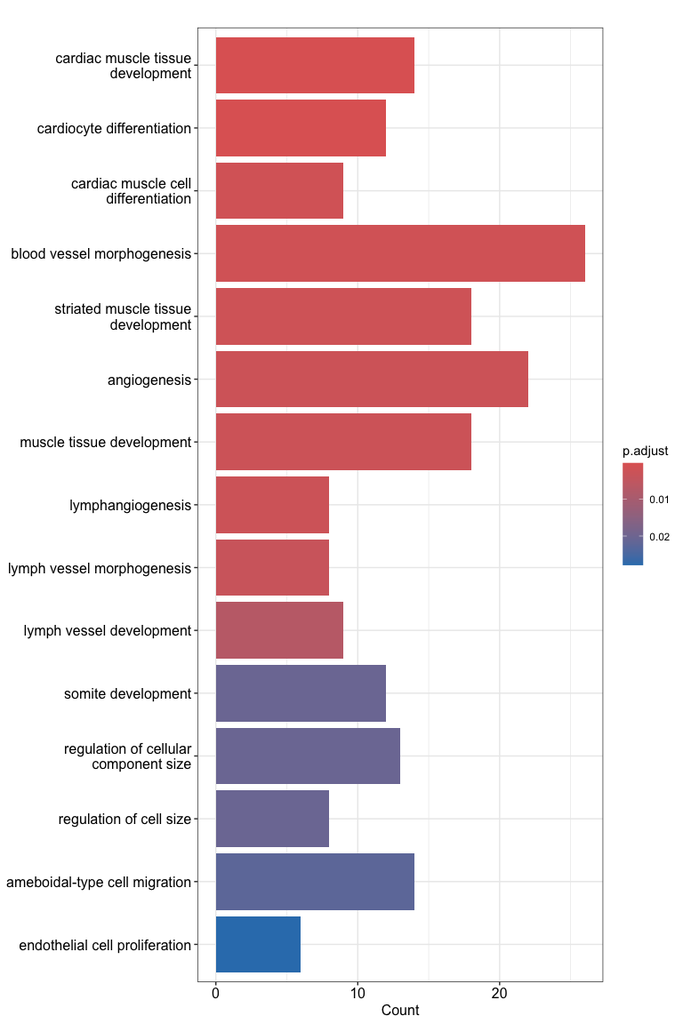

*PDF saved to:* `../output/figure_extended/go//LEC_ego_down_barplot.pdf`

### 1.6.10 ORA ( down ): Dotplot

Adds gene ratio (fraction of input genes hitting each term) as point size, with colour for significance - more informative than the barplot since it shows both effect size and confidence simultaneously. **Expected:** larger, more significant dots clustering around a coherent biological theme. **Unexpected:** significant terms with very small gene ratios (few genes driving a ‘significant’ result) - treat cautiously as potentially fragile.

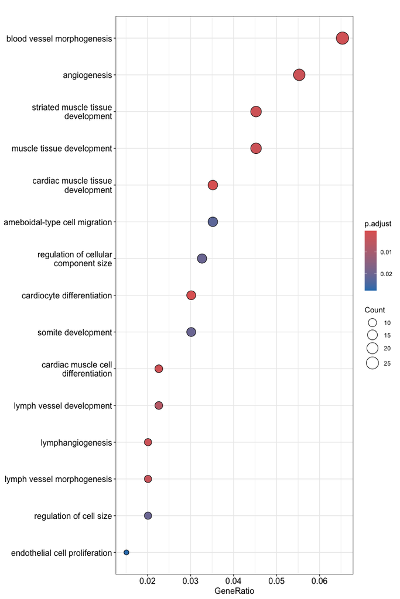

*PDF saved to:* `../output/figure_extended/go//LEC_ego_down_dotplot.pdf`

### 1.6.11 ORA ( down ): Enrichment map

Network graph connecting GO terms that share overlapping genes - clusters of connected terms suggest a shared underlying biological process rather than independent findings. **Expected:** tight clusters of related terms. **Unexpected:** many isolated, unconnected terms, suggesting the significant terms are thematically scattered rather than coherent.

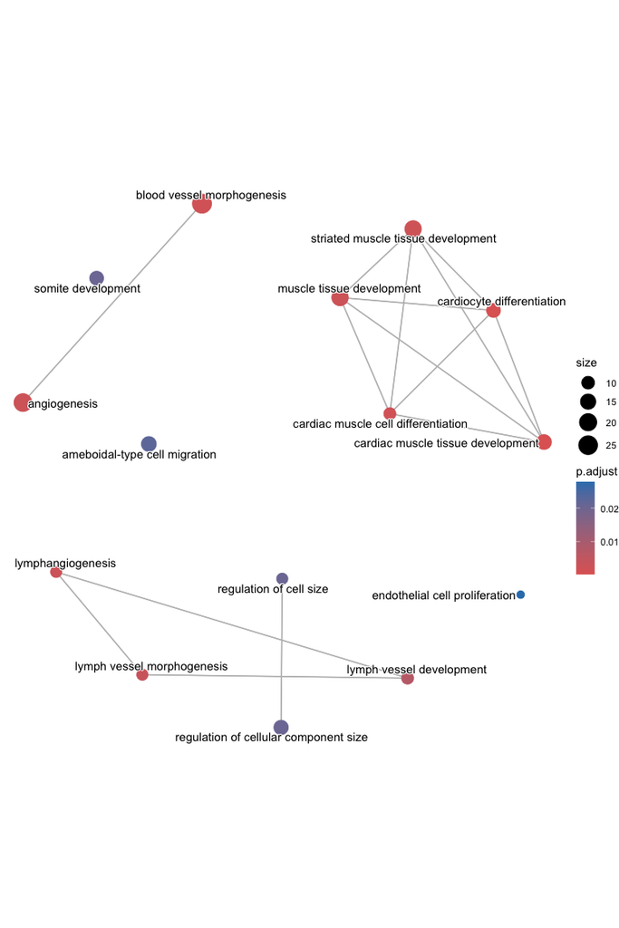

*PDF saved to:* `../output/figure_extended/go//LEC_ego_down_emapplot.pdf`

### 1.6.12 ORA ( down ): Category-gene network

Shows which specific genes drive which enriched terms, useful for tracing a term back to the actual DE genes behind it. **Expected:** recognisable marker genes linking to expected terms. **Unexpected:** a term driven entirely by one or two genes rather than a broad gene set - weaker evidence than a term supported by many genes.

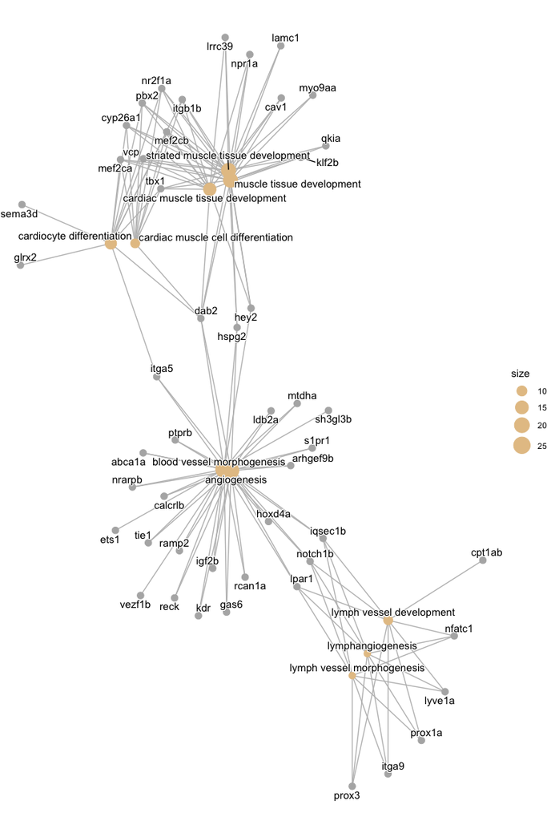

*PDF saved to:* `../output/figure_extended/go//LEC_ego_down_cnetplot.pdf`

**Done:** LEC

```r
cat("### Custom plots for downregulated genes in mutant vs wildtype\n\n")
```

### 1.6.13 Custom plots for downregulated genes in mutant vs wildtype

```r
ego_lec <- singles_LEC_out$ego_result_down@result
ego_lec$GeneRatio_numeric <- sapply(
    strsplit(ego_lec$GeneRatio, "/"), function(x) as.numeric(x[1]) / as.numeric(x[2])
    )
ego_lec_top15_terms <- ego_lec[
    order(-ego_lec$GeneRatio_numeric), ][1:15,
    ]
ego_lec_top15_gene_map <- setNames(strsplit(
    ego_lec_top15_terms$geneID, "/"), ego_lec_top15_terms$Description
    )
ego_lec_top15_gene_list <- unique(unlist(unname(ego_lec_top15_gene_map)))

ego_lec_top15_pathways <- data.frame(ego_lec$ID, ego_lec$Description, ego_lec$geneID)

ego_lec_top15_gene_list <- ego_lec_top15_gene_list[
    grep(":", ego_lec_top15_gene_list, invert=TRUE)
    ]

cat("\n\nDotplots of gene ratio top 15 only.\n\n")
```

Dotplots of gene ratio top 15 only.

```r
cat("Adds gene ratio (fraction of input genes hitting each term) as point size, with colour ",
    "for significance - more informative than the barplot since it shows both effect size and ",
    "confidence simultaneously. **Expected:** larger, more significant dots clustering around a ",
    "coherent biological theme. **Unexpected:** significant terms with very small gene ratios ",
    "(few genes driving a 'significant' result) - treat cautiously as potentially fragile.\n\n")
```

Adds gene ratio (fraction of input genes hitting each term) as point size, with colour for significance - more informative than the barplot since it shows both effect size and confidence simultaneously. **Expected:** larger, more significant dots clustering around a coherent biological theme. **Unexpected:** significant terms with very small gene ratios (few genes driving a ‘significant’ result) - treat cautiously as potentially fragile.

```r
cat("\n\n_Suggested figure legend:_ Dotplot shows the effect size and confidence simultaneously for enriched GO terms. Units on the horizontal axis correspond to the fraction of input genes which hit each GO term. Point size corresponds to the quantity of terms, and point colour corresponds to adjusted p values. Top 15 GO terms by gene ratio are shown.\n\n")
```

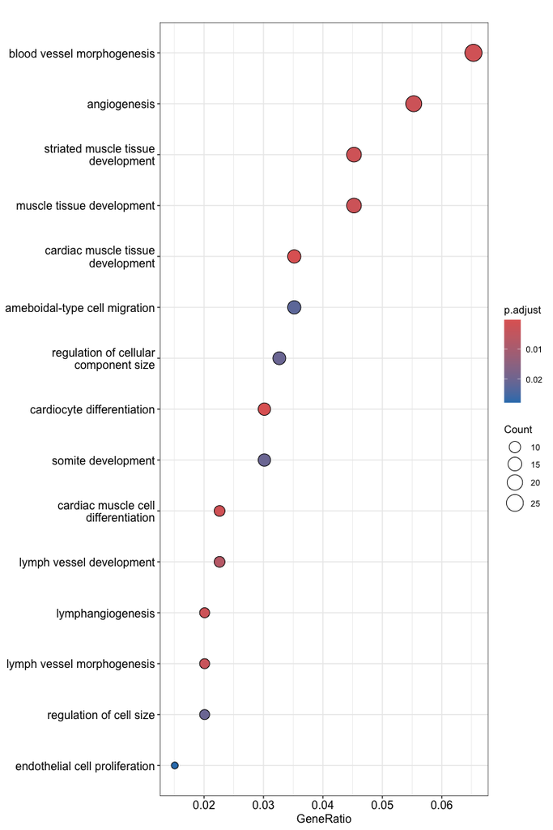

```r
plt_name <- "top15_LEC_GO_pathways_downregulated_generatio_dotplot"
plt <- dotplot(singles_LEC_out$ego_result_down, showCategory=15)
print(plt)
```

```r
save_plot_custom(plt, plt_name)
```

*PDF saved to:* `../output/figure_extended/go//top15_LEC_GO_pathways_downregulated_generatio_dotplot.pdf`

```r
data_lec <- data[, data$L3_celltype == "LEC"]
data_lec$Genotype <- gsub("meox1_mutant", "mutant", data_lec$Genotype)
data_lec$Genotype <- gsub("wildtype", "sibling", data_lec$Genotype)
data_lec$Genotype <- factor(
    data_lec$Genotype,
    levels = c("sibling", "mutant")
)

cat("\n\n**Genotype counts (cells) for LEC singles:**",
    paste(names(table(data_lec$Genotype)), table(data_lec$Genotype), sep = " = ", collapse = ", "),
    "\n\n")
```

**Genotype counts (cells) for LEC singles:** sibling = 285, mutant = 231

```r
cat("\n\nDotplots of gene expression (key pathways).\n\n")
```

Dotplots of gene expression (key pathways).

```r
cat("For plot expansion, settled on these:\n\n
1. selected top 15 pathways as a cutoff\n
2. extracted the genes associated with these\n
3. removed genes with the `[a-z]+:` prefix\n
4. selected genes associated with key pathways and added meox1\n
5. plotted dotplots on the remainder\n\n

Attempted heatmaps, not very useful.\n\n")
```

For plot expansion, settled on these:

1. selected top 15 pathways as a cutoff
2. extracted the genes associated with these
3. removed genes with the `[a-z]+:` prefix
4. selected genes associated with key pathways and added meox1
5. plotted dotplots on the remainder

Attempted heatmaps, not very useful.

```r
cat("\n\n_Suggested figure legend:_ Dotplot shows the scaled expression level for available genes from enriched GO terms. Units on the horizontal axis correspond to the genotypes. Point size corresponds to the percent of expression in each cell group, and point colour corresponds to average expression z-scores. Genes were selected by membership in key pathways detected by gene enrichment and ontology analyses: lymphoangiogenesis, lymph vessel morphogenesis, lymph vessel development, angiogenesis, and blood vessel morphogenesis. In addition, meox1 is shown for reference.\n\n")
```

*Suggested figure legend:* Dotplot shows the scaled expression level for available genes from enriched GO terms. Units on the horizontal axis correspond to the genotypes. Point size corresponds to the percent of expression in each cell group, and point colour corresponds to average expression z-scores. Genes were selected by membership in key pathways detected by gene enrichment and ontology analyses: lymphoangiogenesis, lymph vessel morphogenesis, lymph vessel development, angiogenesis, and blood vessel morphogenesis. In addition, meox1 is shown for reference.

```r
cat("\n\n_Caution against overinterpretation:_ Not an invalid result, but the scale may exaggerate the magnitude of difference.\n
The dotplots look very clean but theres some important nuance\n
1. the pathway genes are sourced from DEG so these would naturally be different
2. the expression values on the dotplot are z-score values and the relatively low scale indicates that the magnitude of the expression isnt massively different (but still different enough)\n\n")
```

*Caution against overinterpretation:* Not an invalid result, but the scale may exaggerate the magnitude of difference.

The dotplots look very clean but theres some important nuance

1. the pathway genes are sourced from DEG so these would naturally be different
2. the expression values on the dotplot are z-score values and the relatively low scale indicates that the magnitude of the expression isnt massively different (but still different enough)

```r
# plot gene expr
plt_name <- "top15_LEC_GO_pathways_downregulated_geneexpr_dotplot_curated"
ego_lec_pathways <- c(
    "lymphangiogenesis",
    "lymph vessel morphogenesis",
    "lymph vessel development",
    "angiogenesis",
    "blood vessel morphogenesis"
    )
ego_lec_selected_rows <- ego_lec_top15_pathways[
    ego_lec_top15_pathways$ego_lec.Description %in% ego_lec_pathways,
    ]
ego_lec_genes_per_pathway <- setNames(
    strsplit(ego_lec_selected_rows$ego_lec.geneID, "/"),
    ego_lec_selected_rows$ego_lec.Description
    )
ego_lec_genes_per_pathway <- c(unique(
    unlist(ego_lec_genes_per_pathway)
    ), "meox1")
cat("\nGene quantity: ", length(ego_lec_genes_per_pathway))
```

Gene quantity: 33

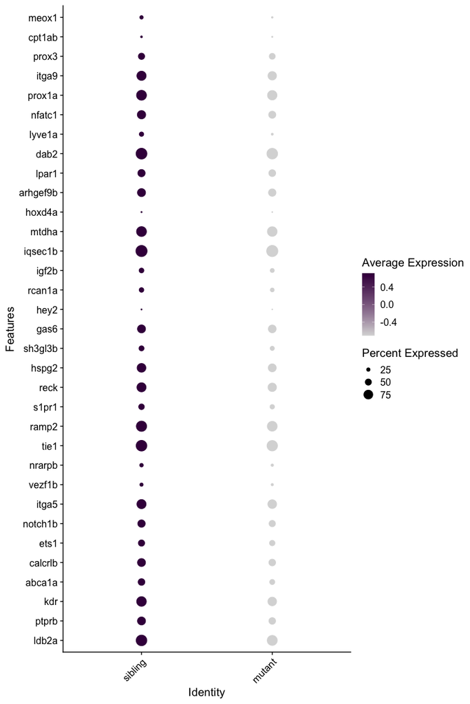

```r
plt <- DotPlot(data_lec, features=ego_lec_genes_per_pathway,
    group.by="Genotype", cols=c("#d9d9d9",  "#40004b")
    ) +
    coord_flip() +
    theme(axis.text.x = element_text(angle = 45, vjust = 1, hjust = 1))
print(plt)
```

```r
save_plot_custom(plt, plt_name, height=12, width=4)
```

*PDF saved to:* `../output/figure_extended/go//top15_LEC_GO_pathways_downregulated_geneexpr_dotplot_curated.pdf`

```r
cat("\n\n_Suggested figure legend:_ Violin plot shows the log2 normalised expression level for differentially expressed genes associated with enriched GO terms. Units on the horizontal axis correspond to the genotypes. Genes were selected by membership in key pathways detected by gene enrichment and ontology analyses: lymphoangiogenesis, lymph vessel morphogenesis, lymph vessel development, angiogenesis, and blood vessel morphogenesis. In addition, meox1 is shown for reference.\n\n")
```

*Suggested figure legend:* Violin plot shows the log2 normalised expression level for differentially expressed genes associated with enriched GO terms. Units on the horizontal axis correspond to the genotypes. Genes were selected by membership in key pathways detected by gene enrichment and ontology analyses: lymphoangiogenesis, lymph vessel morphogenesis, lymph vessel development, angiogenesis, and blood vessel morphogenesis. In addition, meox1 is shown for reference.

```r
cat("\n_Tyrone: Not every single canonical gene associated with the pathway will be shown. It is a function of the data, only the differentially expressed genes associated with the GO term will be shown._\n\n")
```

*Tyrone: Not every single canonical gene associated with the pathway will be shown. It is a function of the data, only the differentially expressed genes associated with the GO term will be shown.*

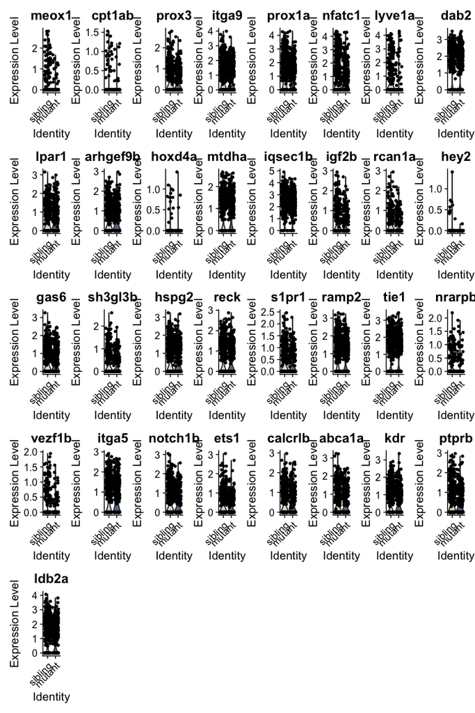

```r
plt_name <- "top15_LEC_GO_pathways_downregulated_geneexpr_vlnplot_curated"
plt <- VlnPlot(
    data_lec,
    features = rev(ego_lec_genes_per_pathway),
    group.by = "Genotype",
    pt.size = 1,
    ncol = 8,
    flip = TRUE,
    cols = c("#dbe2c6", "#657c95")
) + scale_fill_manual(values = c("#dbe2c6", "#657c95")) +
    theme(axis.text.x = element_text(angle = 45, vjust = 1, hjust = 1))
print(plt)
```

```r
save_plot_custom(plt, plt_name, height=12, width=16)
```

*PDF saved to:* `../output/figure_extended/go//top15_LEC_GO_pathways_downregulated_geneexpr_vlnplot_curated.pdf`

```r
singles_pre_muLEC_out <- run_go(singles_pre_muLEC, data_name="pre_muLEC")
```

## 1.7 GO analysis: pre_muLEC

Input genes: 16252

**ORA input genes:** combined = 753 up = 426 down = 327

**ORA (combined):** 2006 terms **ORA (up):** 1582 terms **ORA (down):** 1222 terms

*Full ORA ( combined ) table saved to:* `../output/figure_extended/go//pre_muLEC_ego_combined_full_results.csv`

*Full ORA ( up ) table saved to:* `../output/figure_extended/go//pre_muLEC_ego_up_full_results.csv`

*Full ORA ( down ) table saved to:* `../output/figure_extended/go//pre_muLEC_ego_down_full_results.csv`

**ORA significant terms:** combined = 48 , up = 64 , down = 4

*Significant-only ORA ( combined ) table saved to:* `../output/figure_extended/go//pre_muLEC_ego_combined_significant_only.csv`

*Significant-only ORA ( up ) table saved to:* `../output/figure_extended/go//pre_muLEC_ego_up_significant_only.csv`

*Significant-only ORA ( down ) table saved to:* `../output/figure_extended/go//pre_muLEC_ego_down_significant_only.csv`

### 1.7.1 ORA ( combined ): Barplot

Shows the top enriched GO terms ranked by significance, bar length/colour reflecting adjusted p-value or gene count. **Expected:** terms biologically consistent with the comparison (e.g. vascular/endothelial terms for EC-related contrasts). **Unexpected:** dominance by generic housekeeping terms (translation, metabolism) with no thematic coherence - may indicate a weak or noisy input gene list rather than a real signal.

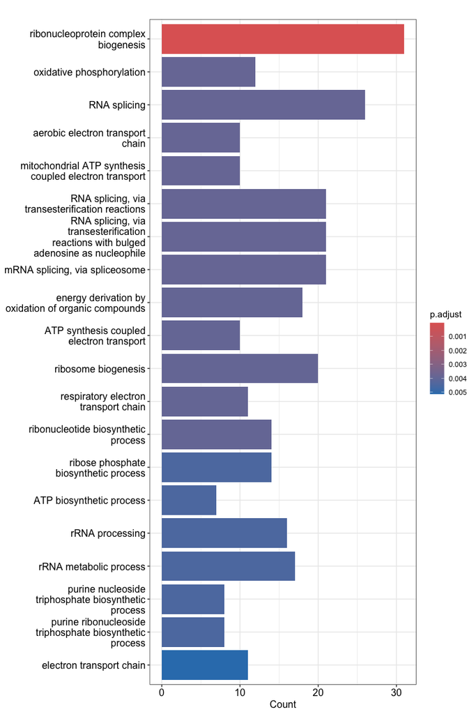

*PDF saved to:* `../output/figure_extended/go//pre_muLEC_ego_combined_barplot.pdf`

### 1.7.2 ORA ( combined ): Dotplot

Adds gene ratio (fraction of input genes hitting each term) as point size, with colour for significance - more informative than the barplot since it shows both effect size and confidence simultaneously. **Expected:** larger, more significant dots clustering around a coherent biological theme. **Unexpected:** significant terms with very small gene ratios (few genes driving a ‘significant’ result) - treat cautiously as potentially fragile.

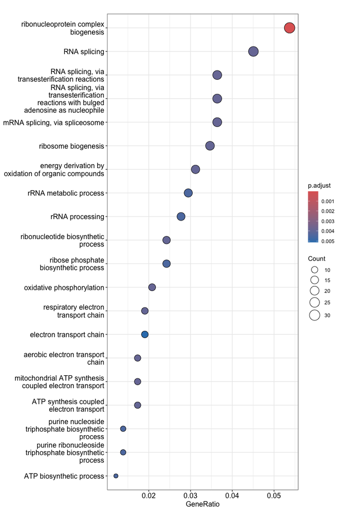

*PDF saved to:* `../output/figure_extended/go//pre_muLEC_ego_combined_dotplot.pdf`